# Random Walk Project

In this project I explore the dynamics of random walks via computational simulation.

Consider a particle which starts at the origin of the $x-y$ plane. This particle will take a series of steps of magnitude 1 in a random direction. What will the particle's trajectory look like?

Below I implement a 2-D random walk function. The angle of the unit step, $\theta$ is taken from a uniform distribution from $[0,2\pi]$.

```python
import random
import numpy as np
import matplotlib.pyplot as plt
```

```python
def randomWalks2D (numSteps):

  #set up a matrix of zeros to store the locations of the random walk
  locations = np.zeros((numSteps+1, 2))

  #take steps and store locations

  for i in range(1, numSteps+1):
    theta = random.random()*2* np.pi #random theta between 0 and 2 pi
    move = np.array([np.cos(theta), np.sin(theta)])
    locations[i] = locations[i-1] + move

  return locations
```

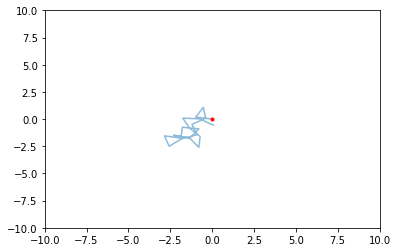

```python
walk = randomWalks2D(20)
plt.plot( walk[:,0], walk[:,1], alpha=0.5 )
plt.plot([0], [0],'r.')
plt.xlim(-10,10)
plt.ylim(-10,10);
```

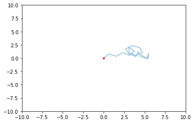

```python
walk = randomWalks2D(20)
plt.plot( walk[:,0], walk[:,1], alpha=0.5 )
plt.plot([0], [0],'r.')
plt.xlim(-10,10)
plt.ylim(-10,10);
```

Above are two separate simulations of the randomWalks2D function. We can see it is working properly.

**1) a) What is the average distance of the random walk from the origin after n steps? Make a plot showing how the average distance of the random walk from the origin depends on n, and find a function that roughly fits your plot.**

```python
def avg_dist(numWalks, numSteps):
  sum = 0
  for i in range(numWalks):
    walk = randomWalks2D(numSteps)
    sum = sum + np.linalg.norm(walk[-1])

  return sum/numWalks
```

```python
list_of_avg_dists = [avg_dist(500, n) for n in range(1, 100)]
```

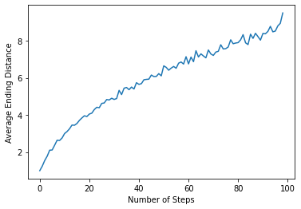

```python
plt.plot(list_of_avg_dists)
plt.xlabel("Number of Steps")
plt.ylabel("Average Ending Distance");
```

The above graph shows the average distance from the center after $n$ steps. Each data point represents 500 simulations. This looks like it could be a square root graph. To check, I will square the values to see if I get a straight line and find the line of best fit.

```python
sq_vals = [d**2 for d in list_of_avg_dists]
```

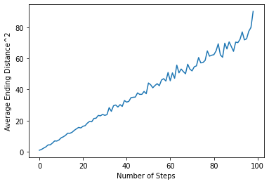

```python
plt.plot(sq_vals)
plt.xlabel("Number of Steps")
plt.ylabel("Average Ending Distance^2");
```

Looks pretty linear! I will find the line of best fit. I will use $\texttt{scipy}$ to find the line of best fit.

```python
from scipy import stats

result = stats.linregress(range(1,100), sq_vals)
result
```

```
LinregressResult(slope=0.7794837440338905, intercept=0.3649916377464777, rvalue=0.9947602039191759, pvalue=6.93612006056966e-98, stderr=0.008134021821916304)
```

```python
m = result.slope
b = result.intercept
```

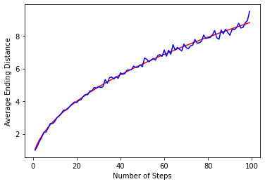

```python
rootFit = [np.sqrt(m*x+b) if m*x+b > 0 else 0 for x in range(1,100)]
plt.plot(range(1,100), rootFit,'r-')
plt.plot(range(1,100), list_of_avg_dists, 'b-')
plt.xlabel("Number of Steps")
plt.ylabel("Average Ending Distance");
```

**(b) Since the walk is not on a grid, it’s very unlikely that it will return exactly to (0, 0). However, it may return to within a circle of radius 1/2 around the origin. What proportion of n-step random walks return at least once to within 1/2 unit of the origin? How does this proportion depend on n? Investigate for various n and make a plot of your results. Do you think that all random walks will eventually return near the origin? Why or why not?**

Below is my implementation. The $\texttt{return_to_origin}$ will take a random walk trajectory and see if any steps after the first step are within $1/2$ of the origin. The $\texttt{prop_return}$ function will run many simulations of a given number of steps and return the porportion of them which returned within $1/2$ of the origin.

```python
def return_to_origin(walk):
  for i in walk[1:]:
    if np.linalg.norm(i) < 1/2:
      return True
  return False
```

```python
def prop_returns(numWalks, numSteps):
  sum = 0
  for _ in range(numWalks):
    walk = randomWalks2D(numSteps)
    if return_to_origin(walk) == True:
      sum = sum + 1
  return sum/ numWalks
```

```python
list_of_prop_returns = [prop_returns(500, n) for n in range(1, 300)]
```

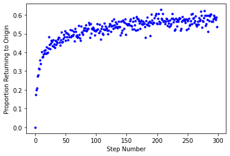

```python
plt.plot(list_of_prop_returns, 'b.');
plt.xlabel("Step Number")
plt.ylabel("Proportion Returning to Origin");
```

**2) What happens if you constrain the random walk to the region −5 ≤ y ≤ 5? Modify your code to keep the y-coordinate of the walk between −5 and 5. You may decide exactly how to implement this modification, but explain your choice and make a few plots of random walks to show that your modified implementation works. Then answer questions (a) and (b) for this constrained random walk.**

To keep the random walk within the region of -5 < y < 5, I will reroll the random steps if the step would make the simulation go outside of the bounds. A rerolled step will not count as a step, so if the number of steps is 10, there will be 10 steps within the bounds.

```python
def constrained_randomWalks2D (numSteps):

  #set up a matrix of zeros to store the locations of the random walk
  locations = np.zeros((numSteps+1, 2))

  #initialize counter
  i = 1


  #changed the for loop to a while loop
  while i <=numSteps:
    theta = random.random()*2* np.pi
    move = np.array([np.cos(theta), np.sin(theta)])
    yloc = locations[i - 1, 1] + np.sin(theta)
    if yloc > -5 and yloc < 5:
      locations[i] = locations[i-1] + move
      i = i + 1 #only increase the counter if a new location is updated



  return locations
```

Here are a few tests to make sure the function is working properly:

```python
randomWalks2D(5)
```

```
array([[ 0.        ,  0.        ],
       [ 0.09257911,  0.99570533],
       [-0.9008849 ,  0.88155952],
       [-1.90020081,  0.84457692],
       [-2.36258823,  1.73125492],
       [-1.65920686,  1.02044225]])
```

```python
constrained_randomWalks2D(5)
```

```
array([[ 0.        ,  0.        ],
       [-0.70106604,  0.71309635],
       [ 0.29678078,  0.77868382],
       [-0.36704162,  1.52657406],
       [-1.35540853,  1.67866238],
       [-2.34890155,  1.56476939]])
```

The size of $\texttt{constrained_randomWalks2D(5)}$ is the same as the original function, so I know that it will work with the other functions I have made above.

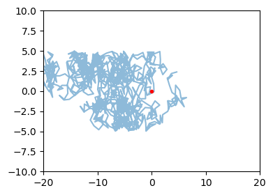

```python
walk = constrained_randomWalks2D(1000)
plt.figure(figsize=(4, 3))
plt.plot( walk[:,0], walk[:,1], alpha=0.5)
plt.plot([0], [0],'r.')
plt.xlim(-20,20)
plt.ylim(-10,10);
```

The plot above shows a random walk with 1000 steps. We can see that the walk is constrained within -5 <y <5 because the walk never steps out of these bounds.

Now that I know this works as intended, let's see how this constrained random walk changed the behavior of the random walk. Let's first take a look at the average distance.

```python
def avg_dist2(numWalks, numSteps):
  sum = 0
  for i in range(numWalks):
    walk = constrained_randomWalks2D(numSteps)
    sum = sum + np.linalg.norm(walk[-1])

  return sum/numWalks
```

```python
list_avg_dist2= [avg_dist2(500, n) for n in range(1, 100)]
```

```python
plt.figure(figsize=(4, 3))
plt.plot(list_avg_dist2)
plt. xlabel("Step Number")
plt. ylabel("Average Distance");
```

[output not shown]

The average distance for the constrained random walk has a similar shape to the unconstrained walk. Let's see what they look like on top of each other.

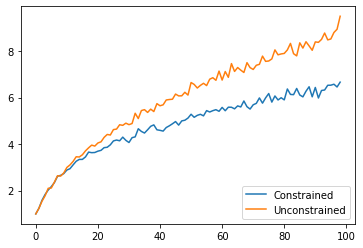

```python
plt.plot(list_avg_dist2, label = "Constrained")
plt.plot(list_of_avg_dists, label = "Unconstrained")
plt.legend(loc = "lower right");
```

It looks like the two curves start to deviate around 15 steps.

I will also find the curve of best fit like before.

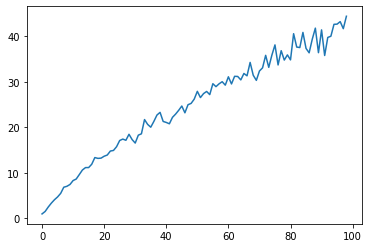

```python
sq_vals2 = [d**2 for d in list_avg_dist2]
plt.plot(sq_vals2)
```

This curve almost looks linear, like the unconstrained walk. I will find the equation that best fits this:

```python
slop = stats.linregress(range(1,100), sq_vals2).slope
print(slop)
intercept = stats.linregress(range(1,100), sq_vals2).intercept
print(intercept)
```

```
0.39849665802616036
4.8793205200891805
```

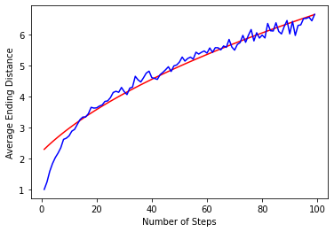

```python
rootFit2 = [np.sqrt(slop*x+intercept) if m*x+b > 0 else 0 for x in range(1,100)]
plt.plot(range(1,100), rootFit2,'r-')
plt.plot(range(1,100), list_avg_dist2, 'b-')
plt.xlabel("Number of Steps")
plt.ylabel("Average Ending Distance");
```

Clearly, this graph does not follow a curve like $y = a\sqrt{x}$. I will see if a different exponential fits the data better.

If the data follows a curve that looks like $$y = A x^B,$$ then $$\log(y) = \log(A) + B \log(x)$$ which is an equation of a line, and we know how to find the parameters for a line. I will use this to find $A$ and $B$.

```
A =  1.0958975146963732
B =  0.39194147957097547
```

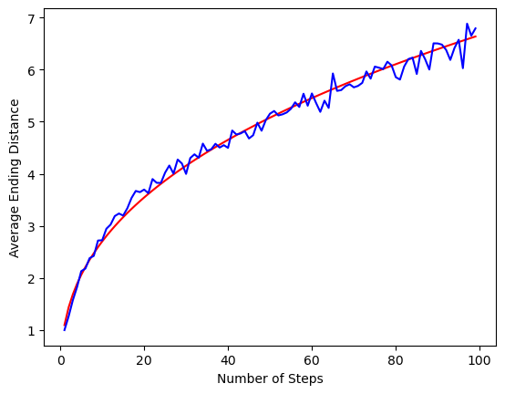

```python
from scipy import stats
log_avg_dist2 = [np.log(d) for d in list_avg_dist2]
slope = stats.linregress(np.log(range(1,100)), log_avg_dist2).slope
intercept = stats.linregress(np.log(range(1,100)), log_avg_dist2).intercept

A = np.exp(intercept)
B = slope

fit = [A*x**B for x in range(1,100)]

plt.plot(range(1,100), fit,'r-')
plt.plot(range(1,100), list_avg_dist2, 'b-')
plt.xlabel("Number of Steps")
plt.ylabel("Average Ending Distance")

print('A = ',A)
print('B = ',B)
```

The average ending distance follows the curve $y = 1.09 x^{0.39}$ nicely.

Now, let's find how often the constrained walk returns $1/2$ unit ball.

```python
def prop_returns2(numWalks, numSteps):
  sum = 0
  for _ in range(numWalks):
    walk = constrained_randomWalks2D(numSteps)
    if return_to_origin(walk) == True:
      sum = sum + 1
  return sum/ numWalks
```

```python
list_con_returns= [prop_returns2(500, n) for n in range(1, 300)]
```

[figure not shown]

```python
plt.plot(list_con_returns, 'r.')
plt.plot(list_of_prop_returns, 'b.')
plt.xlabel("Number of Steps")
plt.ylabel("Proportion Returning to Origin");
```

Above, in blue have the porportion of random walks that return to a sphere of radius 1/2 centered at the origin for various step sizes for the unconstrained walk, and in red I have the same plot for the constrained walk. We can see that initially the two have the same path, but as the step number increases, the constrained one is more likely to return to the center. This makes sense, because the constrained walks will not go farther than +/- 5 in the y direction, so you would expect more of them to return to the origin than the unconstrained version.

**3) Investigate the average diameter for both the constrained and unconstrained random walks.**

The diameter of a given walk is the largest distance away from the center for a given walk. I expect this will be different than the average distance which I have looked at above.

My implementation is below.

```python
 # get the largest distance away in a given walk
 def diameter(walk):
  dia_list = np.zeros(len(walk))
  for i in range(len(walk)):
     dia_list[i] = np.linalg.norm(walk[i])
  return max(dia_list)

# avg_diameter where I can choose which random walk I want, constrained or unconstrained
def avg_diameter(numSteps, numWalks, constraint):
  sum = 0
  for _ in range (numWalks):
    if constraint== True:
      walk = constrained_randomWalks2D(numSteps)
    if constraint== False:
      walk = randomWalks2D(numSteps)

    sum = sum + diameter(walk)

  return sum/numWalks
```

```python
con_list_dias = [avg_diameter(n , 500, True) for n in range (1, 100)]
un_list_dias = [avg_diameter(n, 500, False) for n in range(1,100)]
```

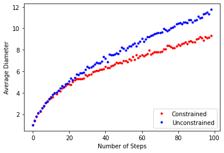

```python
plt.plot(con_list_dias, 'r.', label = "Constrained")
plt.plot(un_list_dias, 'b.', label = "Unconstrained")
plt.xlabel("Number of Steps")
plt.ylabel("Average Diameter")
plt.legend(loc = "lower right");
```

Just like for the ending distances, the diameters of the unconstrained random walks ended up farther away than the constrained random walks. My hypothesis for why this is is because some of the y component of the the random steps for the constrained version are rerolled so they are alwasy within -5 to 5, so taking the magnitude of this will be smaller than if it was unconstrained.